# A Discriminating Labor Union

A powerful labor union may be able to act as a perfectly discriminating monopoly and capture all the consumer surplus. Because it is difficult to charge different prices for each hour of labor services, unions use an alternative approach. The union sets both a wage and a minimum number of hours (Leontief 1946).

As shown in the diagram, if the labor market were competitive, a wage of w would be charged, and H hours of labor services would be sold. Purchasers of labor services would have consumer surplus equal to areas A and B. If, in contrast, all workers belong to a union, and the union acts like a perfectly discriminating monopoly, it charges a wage equal to the demand curve for each hour of labor services it sells (so that the wage for the last hour it sells is w), and it captures all the consumer surplus.

Alternatively, the union could set a single wage, w*, and a minimum number of hours, H, and receive the same total amount of compensation. The union offers the firms the following choice: You may buy H hours of labor at w* (so the total wage bill is Hw*) or you may buy no hours at all. As shown in the diagram, if the union only set the wage at and did not set a minimum number of hours, firms would purchase fewer hours (H*). The only reason that the firms agree to buy so many hours at this wage is that the alternative is to buy no labor services at all.

As the diagram shows, the firms receive consumer surplus equal to area A for the first H* hours, and then have negative consumer surplus (equal to area C) for the next H - H* hours. The union receives profits above the competitive level equal to areas B and C. If w* is set appropriately so that area A equals area C, the union makes as much profit with this scheme as it would if it perfectly price discriminated.

The Longshoremen’s union used this technique (U.S. Department of Labor 1975). Two-thirds of the union contracts in the transportation industry (excluding railroads and airplanes) had wage-employment guarantees in the early 1970s. In contrast, only 11 percent of union contracts in all industries had such guarantees.

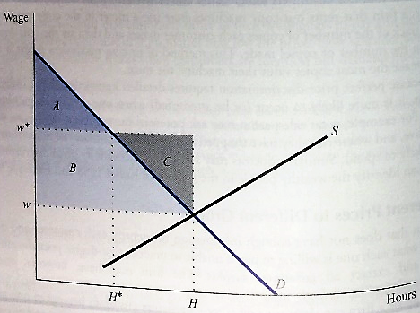